# Analysis of Customer Loan re-payment History and predicting credit risk & Customer Segmentation.

#### Current_instalment_sequence is from range 10 to 60 spread when current outstanding is betweeen 0.0 to 0.4

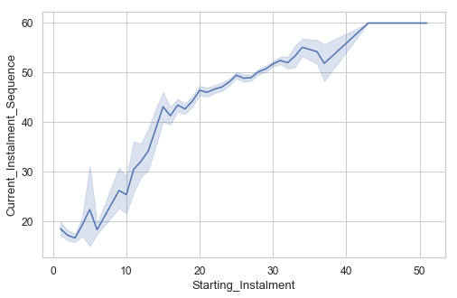

```python
sns.lineplot(x=merged_df['Starting_Instalment'], y=merged_df['Current_Instalment_Sequence']);
```

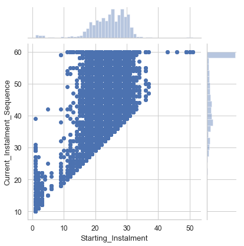

```python
sns.jointplot(x=merged_df['Starting_Instalment'], y=merged_df['Current_Instalment_Sequence']);
```

#### As the Starting_instalment increases the currentinstallment also increases but after 40 as the starting installment increases the current installment sequence remains constant

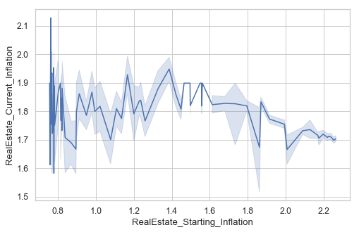

```python
sns.lineplot(x=merged_df['RealEstate_Starting_Inflation'], y=merged_df['RealEstate_Current_Inflation']);
```

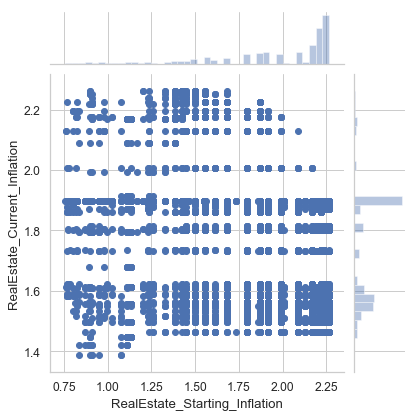

```python
sns.jointplot(x=merged_df['RealEstate_Starting_Inflation'], y=merged_df['RealEstate_Current_Inflation']);
```

#### RealEstate_Current_Inflaton is at its maximum when Starting _Inflation is below 0.8,then it is almost constant wheras starting infation increases

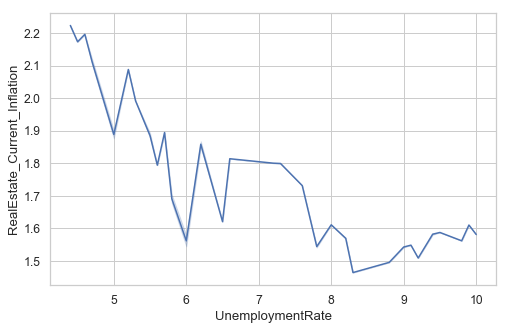

```python
sns.lineplot(x=merged_df['UnemploymentRate'], y=merged_df['RealEstate_Current_Inflation']);
```

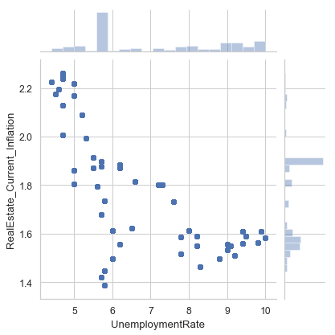

```python
sns.jointplot(x=merged_df['UnemploymentRate'], y=merged_df['RealEstate_Current_Inflation']);
```

### As the reaslEstate_Current_inflation rate decreases unemployemate rate increases

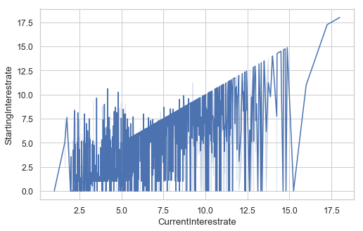

```python
sns.lineplot(x=merged_df['CurrentInterestrate'], y=merged_df['StartingInterestrate']);
```

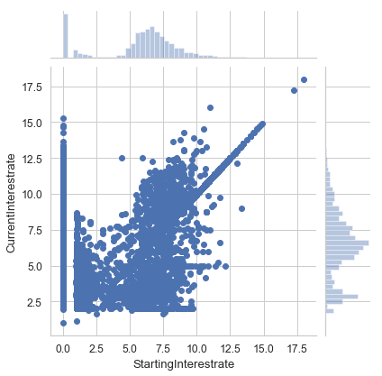

```python
sns.jointplot(x=merged_df['StartingInterestrate'], y=merged_df['CurrentInterestrate']);
```

#### there is positive correlation between current and starting interest rate

### Reading test data and merging test and test payment data

```python
test_payment_his = pd.read_excel('C:\\Users\\dell\\Desktop\\PHD_ML\\Test_PaymentHistory-1557294848030.xlsx')
test = pd.read_excel('C:\\Users\\dell\\Desktop\PHD_ML\\Test-1557294637283.xlsx')
```

```python
test2=test.set_index('CustomerID')
```

```python
test.columns
```

```
Index(['CustomerID', 'DOB', 'Salary', 'ProfessionalLicensure',
       'UtilitySpending', 'eCommerceAccount', 'SocialMediaAccount',
       'NoOfProperties'],
      dtype='object')
```

```python
lastpayment1= test_payment_his.groupby('CustomerID').tail(1)
customer_payment_test=test2.join(lastpayment1.set_index('CustomerID'))
```

```python
customer_payment_test.isnull().sum(axis=0)
```

```
DOB                                       0
Salary                                    0
ProfessionalLicensure                     0
UtilitySpending                           0
eCommerceAccount                          0
SocialMediaAccount                        0
NoOfProperties                            0
Current_Instalment_Sequence               0
Starting_Instalment                       0
Maturity_Period                           0
Current_Outstanding                       0
Current_Loan_to_Appraisedvalu_Percent     0
CurrentInterestrate                       0
RealEstate_Current_Inflation              0
GDP                                       0
UnemploymentRate                          0
Asset_type                                0
Urban_Development                         0
Villa_House                               0
Investment_SelfOccupied                   0
Starting_outstanding                      0
Starting_Loan_to_Appraisedvalu_Percent    0
StartingInterestrate                      0
RealEstate_Starting_Inflation             0
Payment_Status                            0
dtype: int64
```

```python
customer_payment_test.shape
```

```
(2774, 25)
```

### coverting the DOB column to AGE

```python
import datetime as DT

now = pd.Timestamp('now')
customer_payment_test['DOB'] = pd.to_datetime( customer_payment_test['DOB'], format='%Y-%m-%d')
customer_payment_test['DOB'] =  customer_payment_test['DOB'].where( customer_payment_test['DOB'] < now, customer_payment_test['DOB'] -  np.timedelta64(100, 'Y'))
customer_payment_test['DOB'] = (now -  customer_payment_test['DOB']).astype('<m8[Y]')
```

```python
customer_payment_test.rename(columns={"DOB": "Age"}, inplace = True)
```

### Removing the outliers

```python
customer_payment_outlier =merged_df
```

```python
customer_payment_test_outlier = customer_payment_test
```

```python
customer_payment_num_outlier =  customer_payment_outlier.select_dtypes(include=["number"])
customer_payment_num_outlier.columns
```

```
Index(['Age', 'Salary', 'ProfessionalLicensure', 'UtilitySpending',
       'eCommerceAccount', 'NoOfProperties', 'CreditRiskScore',
       'Current_Instalment_Sequence', 'Starting_Instalment', 'Maturity_Period',
       'Current_Outstanding', 'Current_Loan_to_Appraisedvalu_Percent',
       'CurrentInterestrate', 'RealEstate_Current_Inflation', 'GDP',
       'UnemploymentRate', 'Starting_outstanding',
       'Starting_Loan_to_Appraisedvalu_Percent', 'StartingInterestrate',
       'RealEstate_Starting_Inflation'],
      dtype='object')
```

```python
customer_payment_cat_outlier = customer_payment_outlier.select_dtypes(exclude=["number"])
customer_payment_cat_outlier.columns
```

```
Index(['SocialMediaAccount', 'Asset_type', 'Urban_Development', 'Villa_House',
       'Investment_SelfOccupied', 'Payment_Status'],
      dtype='object')
```

```python
from scipy import stats

idx = np.all(stats.zscore(customer_payment_num_outlier) < 3, axis=1)
cus_train_outlier_remove = pd.concat([customer_payment_num_outlier.loc[idx],customer_payment_cat_outlier.loc[idx]], axis=1)
```

```python
cus_train_outlier_remove.shape
```

```
(10050, 26)
```

```python
cus_train_outlier_remove.head(5)
```

| CustomerID | Age | Salary | ProfessionalLicensure | UtilitySpending | eCommerceAccount | NoOfProperties | CreditRiskScore | Current_Instalment_Sequence | Starting_Instalment | Maturity_Period | ... | Starting_outstanding | Starting_Loan_to_Appraisedvalu_Percent | StartingInterestrate | RealEstate_Starting_Inflation | SocialMediaAccount | Asset_type | Urban_Development | Villa_House | Investment_SelfOccupied | Payment_Status |
| --- | --- | --- | --- | --- | --- | --- | --- | --- | --- | --- | --- | --- | --- | --- | --- | --- | --- | --- | --- | --- | --- |
| C12116 | 50.0 | 1238.006112 | 0 | 492.726433 | 1 | 2 | 711 | 48 | 25 | 113 | ... | 45000.0 | 69.4 | 9.20 | 0.8703 | No | No shred services | No | Yes | Self Occupancy | Default |
| C12117 | 38.0 | 1633.000000 | 1 | 477.870359 | 1 | 1 | 767 | 34 | 25 | 138 | ... | 164500.0 | 70.0 | 7.50 | 1.8691 | Yes | No shred services | No | Yes | Self Occupancy | Default |
| C12118 | 49.0 | 1489.000000 | 0 | 351.593736 | 1 | 1 | 827 | 60 | 25 | 105 | ... | 44000.0 | 52.5 | 13.00 | 0.7778 | Yes | No shred services | No | Yes | Self Occupancy | Non-Payoff/Non-Default |
| C12119 | 43.0 | 1241.000000 | 0 | 403.589993 | 1 | 1 | 795 | 60 | 25 | 106 | ... | 34800.0 | 56.9 | 12.35 | 0.7837 | No | Complex With shared services | No | No | Self Occupancy | Non-Payoff/Non-Default |
| C12120 | 44.0 | 1074.000000 | 1 | 406.066005 | 1 | 1 | 827 | 60 | 25 | 107 | ... | 61600.0 | 64.3 | 9.25 | 0.7812 | No | No shred services | No | Yes | Self Occupancy | Non-Payoff/Non-Default |

5 rows × 26 columns

### Droping columns

```python
cus_test_outlier_remove_ID=customer_payment_test_outlier.drop(['SocialMediaAccount','Villa_House','eCommerceAccount','NoOfProperties'],axis=1)
```

```python
cus_train_outlier_remove_ID=cus_train_outlier_remove.drop(['SocialMediaAccount','Villa_House','eCommerceAccount','NoOfProperties'],axis=1)
```

### Dummyfy categorical columns

```python
nominal_columns1= ['Payment_Status','Investment_SelfOccupied','Urban_Development','Asset_type']
dummy_df1 = pd.get_dummies(cus_train_outlier_remove_ID [nominal_columns1])
cus_train_outlier_remove_ID = pd.concat([cus_train_outlier_remove_ID , dummy_df1], axis=1)
cus_train_outlier_remove_ID = cus_train_outlier_remove_ID .drop(nominal_columns1, axis=1)
```

```python
nominal_columns = ['Payment_Status','Investment_SelfOccupied','Urban_Development','Asset_type']
dummy_df = pd.get_dummies(cus_test_outlier_remove_ID [nominal_columns])
cus_test_outlier_remove_ID = pd.concat([cus_test_outlier_remove_ID , dummy_df], axis=1)
cus_test_outlier_remove_ID=cus_test_outlier_remove_ID.drop(nominal_columns, axis=1)
```

```python
cus_train_outlier_remove_ID .head(5)
```

| CustomerID | Age | Salary | ProfessionalLicensure | UtilitySpending | CreditRiskScore | Current_Instalment_Sequence | Starting_Instalment | Maturity_Period | Current_Outstanding | Current_Loan_to_Appraisedvalu_Percent | ... | RealEstate_Starting_Inflation | Payment_Status_Default | Payment_Status_Non-Payoff/Non-Default | Payment_Status_Payoff | Investment_SelfOccupied_Investment | Investment_SelfOccupied_Self Occupancy | Urban_Development_No | Urban_Development_Yes | Asset_type_Complex With shared services | Asset_type_No shred services |
| --- | --- | --- | --- | --- | --- | --- | --- | --- | --- | --- | --- | --- | --- | --- | --- | --- | --- | --- | --- | --- | --- |
| C12116 | 50.0 | 1238.006112 | 0 | 492.726433 | 711 | 48 | 25 | 113 | 29087.21 | 26.658065 | ... | 0.8703 | 1 | 0 | 0 | 0 | 1 | 1 | 0 | 0 | 1 |
| C12117 | 38.0 | 1633.000000 | 1 | 477.870359 | 767 | 34 | 25 | 138 | 160044.34 | 73.431289 | ... | 1.8691 | 1 | 0 | 0 | 0 | 1 | 1 | 0 | 0 | 1 |
| C12118 | 49.0 | 1489.000000 | 0 | 351.593736 | 827 | 60 | 25 | 105 | 34562.30 | 16.897997 | ... | 0.7778 | 0 | 1 | 0 | 0 | 1 | 1 | 0 | 0 | 1 |
| C12119 | 43.0 | 1241.000000 | 0 | 403.589993 | 795 | 60 | 25 | 106 | 27355.73 | 18.466696 | ... | 0.7837 | 0 | 1 | 0 | 0 | 1 | 1 | 0 | 1 | 0 |
| C12120 | 44.0 | 1074.000000 | 1 | 406.066005 | 827 | 60 | 25 | 107 | 43102.83 | 18.516390 | ... | 0.7812 | 0 | 1 | 0 | 0 | 1 | 1 | 0 | 0 | 1 |

5 rows × 27 columns

```python
cus_test_outlier_remove_ID.head()
```

| CustomerID | Age | Salary | ProfessionalLicensure | UtilitySpending | Current_Instalment_Sequence | Starting_Instalment | Maturity_Period | Current_Outstanding | Current_Loan_to_Appraisedvalu_Percent | CurrentInterestrate | ... | RealEstate_Starting_Inflation | Payment_Status_Default | Payment_Status_Non-Payoff/Non-Default | Payment_Status_Payoff | Investment_SelfOccupied_Investment | Investment_SelfOccupied_Self Occupancy | Urban_Development_No | Urban_Development_Yes | Asset_type_Complex With shared services | Asset_type_No shred services |
| --- | --- | --- | --- | --- | --- | --- | --- | --- | --- | --- | --- | --- | --- | --- | --- | --- | --- | --- | --- | --- | --- |
| C41116 | 46.0 | 1876.0 | 1 | 396.161956 | 60 | 25 | 119 | 52686.35 | 34.898842 | 10.500 | ... | 0.9799 | 0 | 1 | 0 | 0 | 1 | 1 | 0 | 0 | 1 |
| C41117 | 49.0 | 1261.0 | 0 | 195.604966 | 60 | 25 | 106 | 20092.00 | 12.903769 | 8.990 | ... | 0.7837 | 0 | 1 | 0 | 0 | 1 | 1 | 0 | 0 | 1 |
| C41118 | 38.0 | 1026.0 | 1 | 212.937051 | 60 | 25 | 141 | 83836.02 | 79.521757 | 6.700 | ... | 2.0886 | 0 | 1 | 0 | 0 | 1 | 1 | 0 | 0 | 1 |
| C41119 | 36.0 | 1384.0 | 0 | 396.161956 | 60 | 25 | 142 | 155180.90 | 91.271715 | 7.500 | ... | 2.0886 | 0 | 1 | 0 | 0 | 1 | 1 | 0 | 0 | 1 |
| C41120 | 40.0 | 1913.0 | 1 | 220.365088 | 60 | 25 | 142 | 58520.11 | 78.598409 | 6.975 | ... | 2.1677 | 0 | 1 | 0 | 0 | 1 | 1 | 0 | 0 | 1 |

5 rows × 26 columns

### Drop Credit

```python
cus_train_outlier_remove_ID_drop=cus_train_outlier_remove_ID[cus_train_outlier_remove_ID.columns.drop('CreditRiskScore')]
```

```python
from sklearn.cluster import KMeans
wcss51=[]
for i in range(1,20):
    kmeans1 = KMeans(n_clusters= i, init='k-means++', random_state=0)
    kmeans1.fit(cus_train_outlier_remove_ID_drop)
    wcss51.append(kmeans1.inertia_)
```

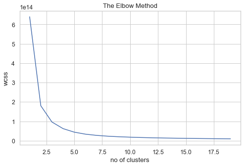

```python
plt.plot(range(1,20), wcss51)
plt.title('The Elbow Method')
plt.xlabel('no of clusters')
plt.ylabel('wcss')
plt.show()
```

```python
kmeans_1=KMeans(n_clusters=3)
kmeans_1.fit(cus_train_outlier_remove_ID_drop)
cluster_pred1=kmeans_1.predict(cus_train_outlier_remove_ID_drop)
cluster_pred_1=kmeans_1.labels_
cluster_center1=kmeans_1.cluster_centers_
```

[figure not shown]

```python
plt.figure(figsize=(10,8))
plt.scatter(cus_train_outlier_remove_ID_drop.iloc[cluster_pred1==0,0],cus_train_outlier_remove_ID_drop.iloc[cluster_pred1==0,1], s = 100, c = 'red', label ='cluster 1' )
plt.scatter(cus_train_outlier_remove_ID_drop.iloc[cluster_pred1==1,0],cus_train_outlier_remove_ID_drop.iloc[cluster_pred1==1,1], s = 100, c = 'blue', label ='cluster 2' )
plt.scatter(cus_train_outlier_remove_ID_drop.iloc[cluster_pred1==2,0],cus_train_outlier_remove_ID_drop.iloc[cluster_pred1==2,1], s = 100, c = 'green', label ='cluster 3' )


plt.scatter(cluster_center1[:,0],cluster_center1[:,1], s = 300, c = 'yellow', label = 'Centroids')
plt.title('Clusters of customers')
plt.xlabel('X ')
plt.ylabel('Y')
plt.legend()
plt.show()
```

### Assigning labels to training data

```python
Cluster_label = cluster_pred_1
```

```python
Train_cluster_removeID_ADD = cus_train_outlier_remove_ID_drop
```

```python
Train_cluster_removeID_ADD['Cluster_label'] = Cluster_label
```

```python
Train_cluster_removeID_ADD.tail()
```

| CustomerID | Age | Salary | ProfessionalLicensure | UtilitySpending | Current_Instalment_Sequence | Starting_Instalment | Maturity_Period | Current_Outstanding | Current_Loan_to_Appraisedvalu_Percent | CurrentInterestrate | ... | Payment_Status_Default | Payment_Status_Non-Payoff/Non-Default | Payment_Status_Payoff | Investment_SelfOccupied_Investment | Investment_SelfOccupied_Self Occupancy | Urban_Development_No | Urban_Development_Yes | Asset_type_Complex With shared services | Asset_type_No shred services | Cluster_label |
| --- | --- | --- | --- | --- | --- | --- | --- | --- | --- | --- | --- | --- | --- | --- | --- | --- | --- | --- | --- | --- | --- |
| C23204 | 39.0 | 1479.701535 | 0 | 237.697174 | 60 | 28 | 146 | 120101.02 | 83.778253 | 6.65 | ... | 0 | 1 | 0 | 0 | 1 | 1 | 0 | 0 | 1 | 1 |
| C23205 | 40.0 | 1221.000000 | 0 | 188.176929 | 42 | 30 | 147 | 91362.13 | 108.792162 | 10.45 | ... | 1 | 0 | 0 | 0 | 1 | 1 | 0 | 0 | 1 | 1 |
| C23206 | 38.0 | 1592.991559 | 0 | 492.726433 | 46 | 27 | 144 | 153847.30 | 138.259645 | 6.50 | ... | 1 | 0 | 0 | 0 | 1 | 1 | 0 | 0 | 1 | 1 |
| C23207 | 37.0 | 2192.559968 | 0 | 237.697174 | 60 | 27 | 144 | 219163.24 | 84.701080 | 7.95 | ... | 0 | 1 | 0 | 0 | 1 | 1 | 0 | 0 | 1 | 0 |
| C23208 | 37.0 | 1694.000000 | 1 | 200.556990 | 60 | 27 | 145 | 92183.89 | 90.551335 | 4.33 | ... | 0 | 1 | 0 | 0 | 1 | 1 | 0 | 0 | 1 | 1 |

5 rows × 27 columns

```python
Train_cluster_removeID_ADD[Train_cluster_removeID_ADD.Cluster_label == 0].head(5)
```

| CustomerID | Age | Salary | ProfessionalLicensure | UtilitySpending | Current_Instalment_Sequence | Starting_Instalment | Maturity_Period | Current_Outstanding | Current_Loan_to_Appraisedvalu_Percent | CurrentInterestrate | ... | Payment_Status_Default | Payment_Status_Non-Payoff/Non-Default | Payment_Status_Payoff | Investment_SelfOccupied_Investment | Investment_SelfOccupied_Self Occupancy | Urban_Development_No | Urban_Development_Yes | Asset_type_Complex With shared services | Asset_type_No shred services | Cluster_label |
| --- | --- | --- | --- | --- | --- | --- | --- | --- | --- | --- | --- | --- | --- | --- | --- | --- | --- | --- | --- | --- | --- |
| C12124 | 37.0 | 1102.182481 | 0 | 430.826127 | 43 | 33 | 141 | 233595.94 | 111.069514 | 10.625 | ... | 1 | 0 | 0 | 0 | 1 | 1 | 0 | 0 | 1 | 0 |
| C12126 | 36.0 | 1958.099896 | 1 | 363.973797 | 52 | 33 | 141 | 181505.99 | 77.236493 | 6.625 | ... | 1 | 0 | 0 | 0 | 1 | 1 | 0 | 0 | 1 | 0 |
| C12130 | 37.0 | 1309.896815 | 1 | 210.461039 | 34 | 25 | 141 | 203389.08 | 93.710308 | 10.250 | ... | 0 | 0 | 1 | 0 | 1 | 1 | 0 | 0 | 1 | 0 |
| C12132 | 40.0 | 1292.000000 | 1 | 232.745149 | 39 | 25 | 141 | 193739.76 | 121.831076 | 8.860 | ... | 1 | 0 | 0 | 0 | 1 | 1 | 0 | 0 | 1 | 0 |
| C12135 | 40.0 | 1558.936012 | 1 | 435.778152 | 40 | 25 | 142 | 268124.50 | 110.306113 | 7.000 | ... | 1 | 0 | 0 | 0 | 1 | 1 | 0 | 0 | 1 | 0 |

5 rows × 27 columns

```python
Train_cluster_removeID_ADD[Train_cluster_removeID_ADD.Cluster_label == 1].head(5)
```

| CustomerID | Age | Salary | ProfessionalLicensure | UtilitySpending | Current_Instalment_Sequence | Starting_Instalment | Maturity_Period | Current_Outstanding | Current_Loan_to_Appraisedvalu_Percent | CurrentInterestrate | ... | Payment_Status_Default | Payment_Status_Non-Payoff/Non-Default | Payment_Status_Payoff | Investment_SelfOccupied_Investment | Investment_SelfOccupied_Self Occupancy | Urban_Development_No | Urban_Development_Yes | Asset_type_Complex With shared services | Asset_type_No shred services | Cluster_label |
| --- | --- | --- | --- | --- | --- | --- | --- | --- | --- | --- | --- | --- | --- | --- | --- | --- | --- | --- | --- | --- | --- |
| C12116 | 50.0 | 1238.006112 | 0 | 492.726433 | 48 | 25 | 113 | 29087.21 | 26.658065 | 9.200 | ... | 1 | 0 | 0 | 0 | 1 | 1 | 0 | 0 | 1 | 1 |
| C12117 | 38.0 | 1633.000000 | 1 | 477.870359 | 34 | 25 | 138 | 160044.34 | 73.431289 | 9.875 | ... | 1 | 0 | 0 | 0 | 1 | 1 | 0 | 0 | 1 | 1 |
| C12118 | 49.0 | 1489.000000 | 0 | 351.593736 | 60 | 25 | 105 | 34562.30 | 16.897997 | 12.125 | ... | 0 | 1 | 0 | 0 | 1 | 1 | 0 | 0 | 1 | 1 |
| C12119 | 43.0 | 1241.000000 | 0 | 403.589993 | 60 | 25 | 106 | 27355.73 | 18.466696 | 12.350 | ... | 0 | 1 | 0 | 0 | 1 | 1 | 0 | 1 | 0 | 1 |
| C12120 | 44.0 | 1074.000000 | 1 | 406.066005 | 60 | 25 | 107 | 43102.83 | 18.516390 | 5.000 | ... | 0 | 1 | 0 | 0 | 1 | 1 | 0 | 0 | 1 | 1 |

5 rows × 27 columns

```python
Train_cluster_removeID_ADD[Train_cluster_removeID_ADD.Cluster_label == 2].head(5)
```

| CustomerID | Age | Salary | ProfessionalLicensure | UtilitySpending | Current_Instalment_Sequence | Starting_Instalment | Maturity_Period | Current_Outstanding | Current_Loan_to_Appraisedvalu_Percent | CurrentInterestrate | ... | Payment_Status_Default | Payment_Status_Non-Payoff/Non-Default | Payment_Status_Payoff | Investment_SelfOccupied_Investment | Investment_SelfOccupied_Self Occupancy | Urban_Development_No | Urban_Development_Yes | Asset_type_Complex With shared services | Asset_type_No shred services | Cluster_label |
| --- | --- | --- | --- | --- | --- | --- | --- | --- | --- | --- | --- | --- | --- | --- | --- | --- | --- | --- | --- | --- | --- |
| C12161 | 37.0 | 1283.945718 | 0 | 418.446066 | 32 | 23 | 141 | 354980.51 | 94.053687 | 9.125 | ... | 1 | 0 | 0 | 0 | 1 | 1 | 0 | 0 | 1 | 2 |
| C12179 | 38.0 | 1127.000000 | 0 | 217.889076 | 41 | 32 | 148 | 405443.08 | 108.428331 | 6.845 | ... | 1 | 0 | 0 | 0 | 1 | 1 | 0 | 1 | 0 | 2 |
| C12180 | 40.0 | 1634.375636 | 0 | 339.213675 | 41 | 32 | 148 | 488315.05 | 121.093401 | 2.425 | ... | 1 | 0 | 0 | 0 | 1 | 1 | 0 | 0 | 1 | 2 |
| C12194 | 38.0 | 4407.388952 | 0 | 361.497785 | 48 | 20 | 138 | 369346.81 | 132.216581 | 5.000 | ... | 1 | 0 | 0 | 0 | 1 | 0 | 1 | 0 | 1 | 2 |
| C12205 | 36.0 | 1954.159645 | 1 | 314.453553 | 42 | 28 | 146 | 522110.52 | 131.043023 | 7.175 | ... | 1 | 0 | 0 | 0 | 1 | 1 | 0 | 0 | 1 | 2 |

5 rows × 27 columns

#### prediction and Assigning label to test data

```python
Test_Cluster_ADD =cus_test_outlier_remove_ID
```

```python
cluster_pred3=kmeans_1.predict(Test_Cluster_ADD)
```

```python
Test_Cluster_ADD['Cluster_label'] = cluster_pred3
```

```python
Test_Cluster_ADD.tail()
```

[output not shown]

5 rows × 27 columns